# `ospgrillage` Super-T Bridge Example

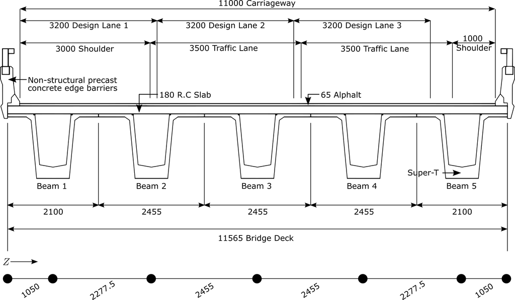

```python
display.Image(b64decode(cross_section_png))
```

Span = 33.5 m; Width = 11.565 m

### Import & Settings

```python
import ospgrillage as og
```

### Units

Establish a consistent set of units - in this case the base units are N and m.

```python
kilo = 1e3
milli = 1e-3
N = 1
m = 1
mm = milli * m
m2 = m ** 2
m3 = m ** 3
m4 = m ** 4
kN = kilo * N
Pa = 1
MPa = N / ((mm) ** 2)
GPa = kilo * MPa
kPa = kilo * Pa
```

### Materials

Create a `Material` object using `create_material()` function.

```python
concrete = og.create_material(material="concrete", code="AS5100-2017", grade="65MPa")
```

Alternatively, users can always create customize concrete material with:

1. Elastic modulus, `E`
2. Possion ratio, `v`
3. Density, `rho`

If shear modulus, $G$, is not defined `ospgrillage` automatically determines the shear modulus using $ G = \frac{E}{2 (1+v)} $

```python
concrete_custom = og.create_material(material="concrete",E=50*GPa, v= 0.3, rho=24*kN/m3 )
```

### Cross Sections

Create a `Section` object for each grillage element using `create_section()` function

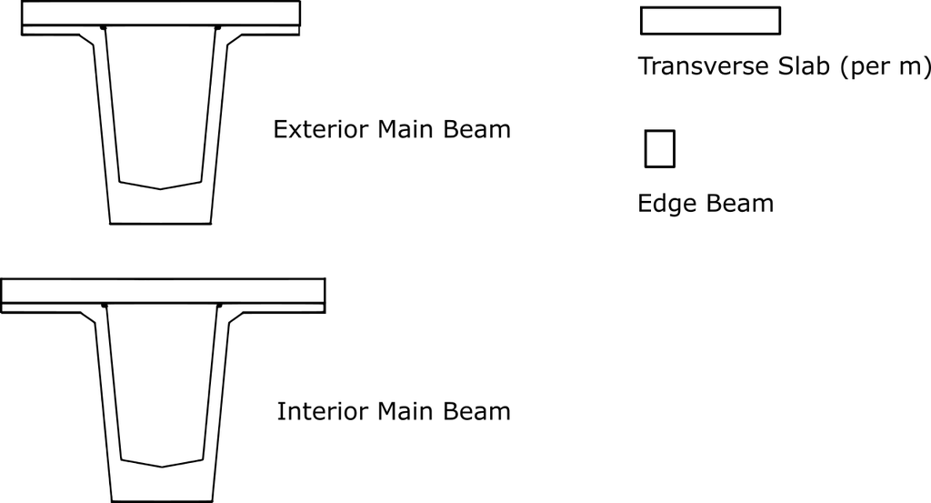

```python
display.Image(b64decode(sections_png))
```

```python
edge_longitudinal_section = og.create_section(
    A=0.934 * m2,
    J=0.1857 * m3,
    Iz=0.3478 * m4,
    Iy=0.213602 * m4,
    Az=0.444795 * m2,
    Ay=0.258704 * m2,
)

longitudinal_section = og.create_section(
    A=1.025 * m2,
    J=0.1878 * m3,
    Iz=0.3694 * m4,
    Iy=0.3634 * m4,
    Az=0.4979 * m2,
    Ay=0.309 * m2,
)

transverse_section = og.create_section(
    A=0.504 * m2,
    J=5.22303e-3 * m3,
    Iy=0.32928 * m4,
    Iz=1.3608e-3 * m4,
    Ay=0.42 * m2,
    Az=0.42 * m2,
    unit_width=True
)

end_transverse_section = og.create_section(
    A=0.504 / 2 * m2,
    J=2.5012e-3 * m3,
    Iy=0.04116 * m4,
    Iz=0.6804e-3 * m4,
    Ay=0.21 * m2,
    Az=0.21 * m2,
)
```

### Grillage Members

Creating grillage members requires:

1. `Material` object
2. `Section` object

```python
longitudinal_beam = og.create_member(section=longitudinal_section, material=concrete)

edge_longitudinal_beam = og.create_member(
    section=edge_longitudinal_section, material=concrete
)
transverse_slab = og.create_member(section=transverse_section, material=concrete)

end_transverse_slab = og.create_member(
    section=end_transverse_section, material=concrete
)
```

### Bridge deck geometry

Here we define the span (`L`), width, (`w`) and skew angle of the edge (`angle`). In addition, we define the properties of the mesh i.e. number of longitudinal members (`n_l`) and transverse members (`n_t`) as well as the distance between the edge beam and first exterior beam (`edge_dist`).

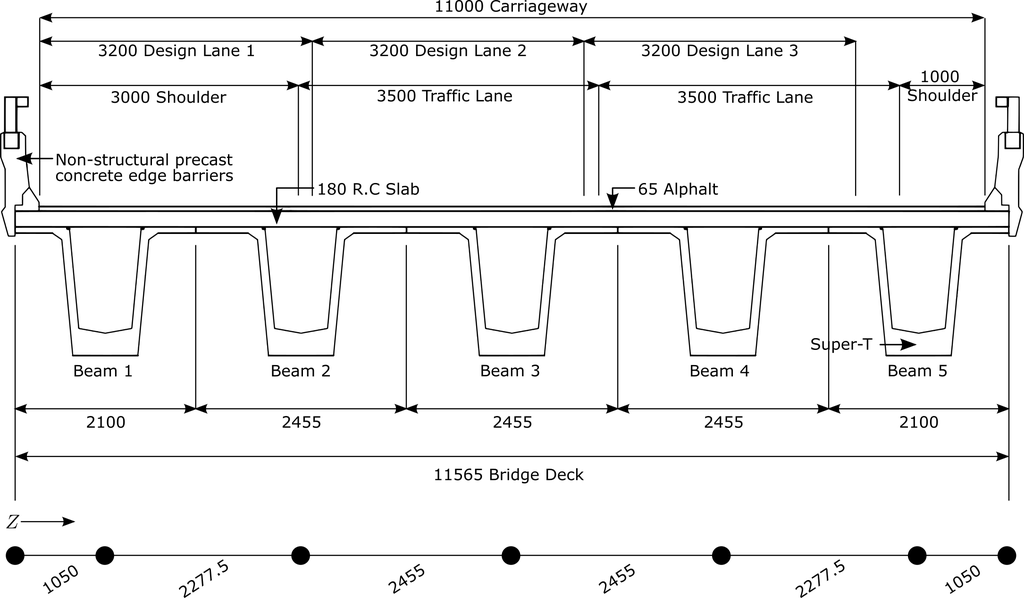

```python
display.Image(b64decode(cross_section_png))
```

```python
L = 33.5 * m                  # span
w = 11.565 * m                # width
n_l = 7                       # number of longitudinal members
n_t = 11                      # number of transverse members
edge_dist = 1.05 * m          # distance between edge beam and first exterior beam
ext_to_int_dist = 2.2775 * m  # distance between first exterior beam and first interior beam
angle = 0                     # skew angle
```

## Create the Grillage Model

Creating model using `create_grillage()` function. Then assigning the defined `GrillageMember`s to the elements using `set_member()` function.

```python
model = og.create_grillage(
    bridge_name="Super-T 33_5m",
    long_dim=L,
    width=w,
    skew=angle,
    num_long_grid=n_l,
    num_trans_grid=n_t,
    edge_beam_dist=edge_dist,
    ext_to_int_dist = ext_to_int_dist,
)
```

```python
# assign grillage member to element groups of grillage model
model.set_member(longitudinal_beam, member="interior_main_beam")
model.set_member(longitudinal_beam, member="exterior_main_beam_1")
model.set_member(longitudinal_beam, member="exterior_main_beam_2")
model.set_member(edge_longitudinal_beam, member="edge_beam")
model.set_member(transverse_slab, member="transverse_slab")
model.set_member(end_transverse_slab, member="start_edge")
model.set_member(end_transverse_slab, member="end_edge")
```

Last step, create the model in OpenSees using:

```python
model.create_osp_model(pyfile=False)
```

### Plot the model

To do this, we pass the model into OpenSeesPy to use its visualization functions.

Plot using the *opsplt* `GetRendering` library.

```
No Model_ODB specified, trying to get data from the active model.
3D model
```

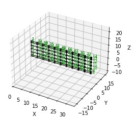

```python
og.opsplt.plot_model("nodes");
```

Plot using `ops_vis` library

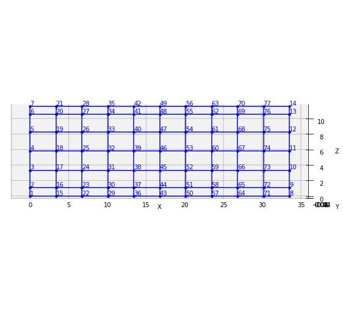

```python
og.opsv.plot_model(az_el=(-90, 0),element_labels=0)
fig = og.plt.gcf()
fig.set_size_inches(8, 8)
og.plt.show()
```

## Adding Load Case

From here, we will add load cases as defined in previous study of Caprani et al. (2017). We will detail the steps to create these load cases (e.g. dead load, and moving load models) in the following section.

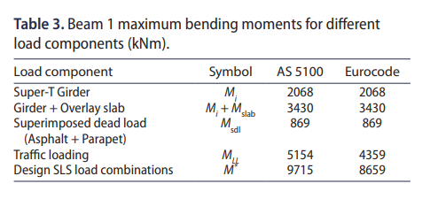

```python
display.Image(b64decode(table_png))
```

(ref: Caprani et al. 2017)

### Dead loads

Dead loads comprise of the self-weight of Super-T girders and overlay slab

For the comparison in this example, we shall split the Super-T girder and overlay slab's load cases into individual load cases.

#### Self-weight of Super-T girders

The self-weight of super-T girders is calculated as follows:

$ w_{girder} = 24 ~ \mathrm{kN/m^3} \times 0.934 ~ \mathrm{m^2} = 22.4 ~ \mathrm{kN/m} $

To this, we create a `LineLoad` and assign along position of longitudinal beams. Note for this example we assume this weight for all beams.

```python
start_beam = 0
end_beam = L
beam_mag = 22.4 * kN / m

# create Super T self weight load case
DL_self_weight = og.create_load_case(name="Super T self weight")

for z_pos in model.Mesh_obj.noz[1:-1]:
    beam_load_position_1 = og.create_load_vertex(x=start_beam, z=z_pos, p=beam_mag)
    beam_load_position_2 = og.create_load_vertex(x=end_beam, z=z_pos, p=beam_mag)

    self_weight_beam = og.create_load(loadtype="line", point1=beam_load_position_1,
                                      point2=beam_load_position_2,)

    DL_self_weight.add_load(self_weight_beam)

model.add_load_case(DL_self_weight)
```

#### Overlay slab

A 180 mm in situ concrete overlay slab forms the deck. The distributed weight (area) of the deck is calculated as:

$ w_{slab} = 0.18 ~ \mathrm{m} \times 24 ~ \mathrm{kN/m^3} = 4.32 ~ \mathrm{kN/m^2} $

We use a `PatchLoad` to define the overlay slab weight.

```python
overlay_p_mag = 4.32 * kN / m2
patch_vertex_1 = og.create_load_vertex(x=0, z=0, p=overlay_p_mag)
patch_vertex_2 = og.create_load_vertex(x=L, z=0, p=overlay_p_mag)
patch_vertex_3 = og.create_load_vertex(x=L, z=w, p=overlay_p_mag)
patch_vertex_4 = og.create_load_vertex(x=0, z=w, p=overlay_p_mag)

overlay_slab = og.create_load(
    loadtype="patch",
    name="overlay",
    point1=patch_vertex_1,
    point2=patch_vertex_2,
    point3=patch_vertex_3,
    point4=patch_vertex_4,
)

DL_overlay = og.create_load_case(name="Overlay self weight")
DL_overlay.add_load(overlay_slab)

model.add_load_case(DL_overlay)
```

### Superimposed Dead loads (SIDL)

Superimposed dead load (SIDL) consist of asphalt surfacing and non-structural precast concrete edge barriers.

#### Asphalt surfacing

The surfacing is 65 mm thick with a self-weight of 22 kN/m$^3$

The magnitude of the asphalt surfacing is calculated as follows:

$ w_{asphalt} = 0.065 ~ \mathrm{m} \times 22 ~ \mathrm{kN/m^3} = 1.43 ~ \mathrm{kN/m^2} $

```python
# asphalt surfacing (units kN/m2) - `patch` in global coords
asphalt_udl = 1.43 * kN / m2

patch_vertex_1 = og.create_load_vertex(x=0, z=0, p=asphalt_udl)
patch_vertex_2 = og.create_load_vertex(x=L, z=0, p=asphalt_udl)
patch_vertex_3 = og.create_load_vertex(x=L, z=w, p=asphalt_udl)
patch_vertex_4 = og.create_load_vertex(x=0, z=w, p=asphalt_udl)

asphalt_surfacing = og.create_load(
    loadtype="patch",
    name="asphat surfacing",
    point1=patch_vertex_1,
    point2=patch_vertex_2,
    point3=patch_vertex_3,
    point4=patch_vertex_4,
)
```

#### Precast edge barriers

The non-structural precast concrete edge barriers weighs 6.54 kN/m.

We use a line load to represent the precast edge barriers on the edge beams.

```python
# precast edge barriers (units kN/m) - `compound` in global coords
barrier_udl = 6.54 * kN/m

left_barrier_p1 = og.create_load_vertex(x=0,z=0,p= barrier_udl)
left_barrier_p2 = og.create_load_vertex(x=L,z=0,p= barrier_udl)
right_barrier_p1 = og.create_load_vertex(x=0,z=w,p= barrier_udl)
right_barrier_p2 = og.create_load_vertex(x=L,z=w,p= barrier_udl)

left_barrier = og.create_load(
    loadtype="line", name="left barrier", point1=left_barrier_p1, point2=left_barrier_p2
)
right_barrier = og.create_load(
    loadtype="line", name="right barrier", point1=right_barrier_p1, point2=right_barrier_p2
)
```

Add both Asphalt and Parapets to a load case called `SIDL`

```python
SIDL = og.create_load_case(name="SIDL")
SIDL.add_load(asphalt_surfacing)
SIDL.add_load(left_barrier)
SIDL.add_load(right_barrier)
model.add_load_case(SIDL)
```

### Australian Traffic Load Model (M1600)

This is a 12-axle moving notional vehicle with central (variable) axle spacing set to 6.25 m and a uniformly distributed load on each standard design lane of 3.2 m (after AS 5100.2).

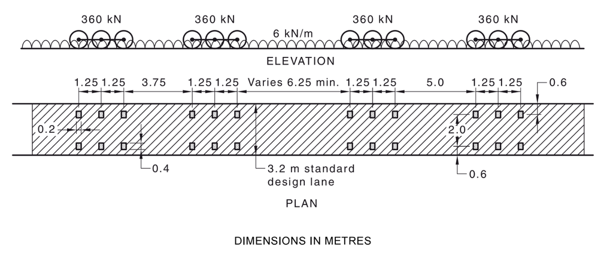

```python
display.Image(b64decode(m1600_png))
```

Thus, the gemoetric properties of the lanes relevant to the lane loading are:

```python
# distance between lane edge and axle in z direction
edge_dist = 0.6 * m

# x and z coordinate of load model origin in global grillage coordinate
x_coord_L1 = 3.5 * m
z_coord_L1 = 1.8825 * m

x_coord_L2 = 3.5 * m
z_coord_L2 = 5.0825 * m

x_coord_L3 = 3.5 * m
z_coord_L3 = 8.2825 * m

x_coord = [x_coord_L1,x_coord_L2,x_coord_L3,]
z_coord = [z_coord_L1,z_coord_L2,z_coord_L3,]
```

Create the load case for M1600

```python
M1600_load_case = og.create_load_case(name="M1600 notional")
```

#### UDL component of M1600

The UDL component shall be created using a Patch object of `ospgrillage`. This patch shall be part of the M1600's `LoadCase` object later on. Note the UDL component is defined in global coordinate.

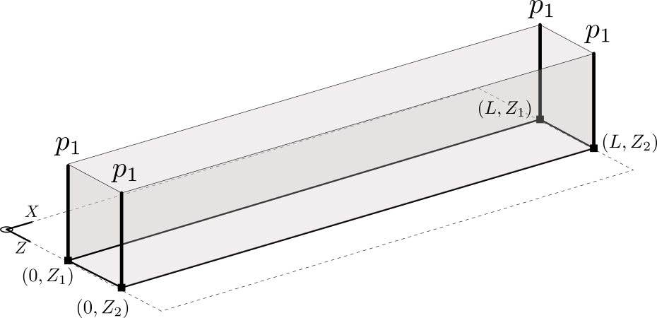

```python
display.Image(b64decode(patch_iso_png))
```

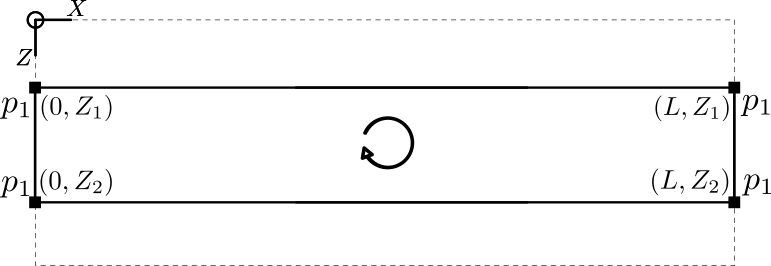

```python
display.Image(b64decode(patch_plane_png))
```

```python
udl_line_load = 6 * kN / m
udl_width = 3.2 * m
# M1600 area load
udl_mag = udl_line_load/udl_width
```

#### M1600 axles

Before creating the notional vehicle, we first define the axle positions (x,z) in local coordinate system

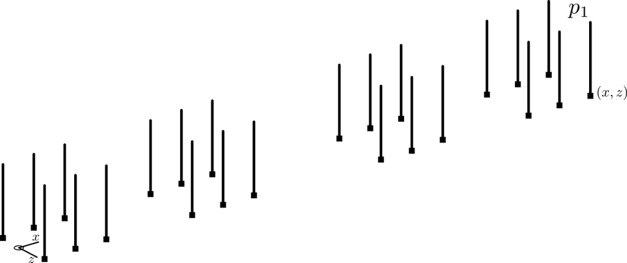

```python
display.Image(b64decode(axles_png))
```

#### Create M1600 vehicle

For this, we use `ospgrillage`'s `CompoundLoad` object. Similar to the UDL component, we can adopt a `for` loop to generate the `PointLoad` of each axle then add to the compound load.

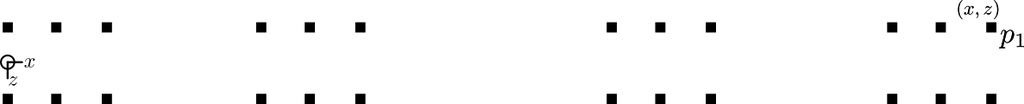

```python
display.Image(b64decode(axle_top_png))
```

Here, `p1` is the 60 kN wheel load.

With `ospgrillage`, users can write generic functions that wraps the `create_load()` function. The following example showcase how we can create the axles using a function. Note for load models, `ospgrillage` v0.1.1 has an API function `create_load_model()` for this M1600 and other types of load model.

```python
def make_M1600_vehicle(gap):
    """
    Makes an M1600 vehicle in local coordinates
    """
    axle_dist = 1.25 * m
    left_group_dist = 3.75 * m
    right_group_dist = 5 * m
    wheel_load = 60*kN

    # Define longitudinal positions of each axle
    load_positions_x = [
        0,
        axle_dist,
        axle_dist * 2,
        left_group_dist + axle_dist * 2 ,
        left_group_dist+ axle_dist * 2  + axle_dist,
        left_group_dist + axle_dist * 2 +  2 * axle_dist,
        gap + left_group_dist + axle_dist * 2 +  2 * axle_dist ,
        gap + left_group_dist + axle_dist * 2 +  2 * axle_dist + axle_dist,
        gap + left_group_dist + axle_dist * 2 +  2 * axle_dist + axle_dist * 2,
        right_group_dist + gap + left_group_dist + axle_dist * 2 +  2 * axle_dist + axle_dist * 2 ,
        right_group_dist + gap + left_group_dist + axle_dist * 2 +  2 * axle_dist + axle_dist * 2  + axle_dist,
        right_group_dist + gap + left_group_dist + axle_dist * 2 +  2 * axle_dist + axle_dist * 2 +  2 * axle_dist,
    ]
    # Transverse position of each wheel
    load_positions_z = [-1, 1]

    M1600_vehicle = og.create_compound_load(name="M1600 Vehicle")
    for z in load_positions_z:
        for x in load_positions_x:
            vert = og.create_load_vertex(x=x, z=z, p=wheel_load)
            point = og.create_load(loadtype="point",name="M1600 point", point1 = vert)
            M1600_vehicle.add_load(load_obj=point)

    return M1600_vehicle
```

According to AS5100, the accompanying lane factor factors for the three design lanes (denoted as L1, L2 and L3) are 1.0, 0.8 and 0.4 respectively.

The dynamic allowance factor of 30% is defined here.

```python
alf = [1.0, 0.8, 0.4]
dla = 1.3
```

And we'll also make a list of the elements that we will move

```python
M1600_moving_loads = []
```

Now, create the M1600 load model for each lane comprising:

- Vehicle
- UDL patch load

We create a `PatchLoad` object and M1600 vehicle on each traffic lane, and add them into a single load case using a `for` loop:

```python
gap = 6.25 * m
m1600_L1_lc = og.create_load_case(name="M1600 L1")
m1600_L2_lc = og.create_load_case(name="M1600 L2")
m1600_L3_lc = og.create_load_case(name="M1600 L3")
m1600_lc_list = [m1600_L1_lc,m1600_L2_lc,m1600_L3_lc]

for i in range(3):
    # Create generic vehicle
    M1600_vehicle_generator = og.create_load_model(model_type="M1600",gap=gap)
    M1600_vehicle_n = M1600_vehicle_generator.create()
    # Position in global coords
    M1600_vehicle_n.set_global_coord(og.Point(x_coord[i], 0, z_coord[i]))
    # And add to the load case with the lane factor
    m1600_lc_list[i].add_load(load_obj=M1600_vehicle_n,load_factor=alf[i])
    # And store in list for moving load
    M1600_moving_loads.append(M1600_vehicle_n)

    # Now create the patch
    vertex_1 = og.create_load_vertex(x=-L, z=z_coord[i] - udl_width/2, p=udl_mag)
    vertex_2 = og.create_load_vertex(x=2*L, z=z_coord[i] - udl_width/2, p=udl_mag)
    vertex_3 = og.create_load_vertex(x=2*L, z=z_coord[i] + udl_width/2, p=udl_mag)
    vertex_4 = og.create_load_vertex(x=-L, z=z_coord[i] + udl_width/2, p=udl_mag)

    M1600_udl = og.create_load(
        loadtype="patch",
        name="M1600 Lane UDL",
        point1=vertex_1,
        point2=vertex_2,
        point3=vertex_3,
        point4=vertex_4,
    )
    m1600_lc_list[i].add_load(load_obj=M1600_udl,load_factor=alf[i])
    model.add_load_case(m1600_lc_list[i],load_factor=dla)
```

### Moving load case

We can make the M1600 into a [moving load case](https://monashsmartstructures.github.io/ospgrillage/rst/Running_analysis.html#moving-load) instead.

#### Create moving path

First we create a `Path` object for the load model. A [path](https://monashsmartstructures.github.io/ospgrillage/_images/movingload.png) is defined using two `Point` named tuple defined either by `create_point()` or directly `Point(x,y,z)`.

Since the origin of the truck compound load coordinate system is at the back axle $x_{local} = 0$ m, we need to place the start point at $x_{global}=-25 $ m and the end point at the end of the bridge.

```python
start = og.create_point(x=-25,y=0,z=0)
end = og.Point(L,0,0)
m1600_path = og.create_moving_path(start_point=start, end_point= end)
```

#### Create moving load

Create moving load object; adding Path and Load components to moving load.

We do this using a `for` loop again. Since the load components of the M1600 have been previously created and stored in `M1600_moving_loads`, we can just add it to the moving load.

```python
moving_load_list = []
for i in range(3):
    name = f"Moving M1600 L{i+1}"
    moving_m1600 = og.create_moving_load(name=name)
    moving_m1600.set_path(m1600_path)
    moving_m1600.add_load(M1600_moving_loads[i])
    model.add_load_case(moving_m1600)
    #add to list for later on
    moving_load_list.append(moving_m1600)
```

The moving load is parsed into load cases for each incremental position in the path. The default increment is 50.

### Analysis

```python
model.analyze()
```

## Post-processing

### Result extraction

Results are output as [Xarray](http://xarray.pydata.org/en/stable/index.html), using `get_results()` function.

```python
results = model.get_results()
results
```

```
<xarray.Dataset>
Dimensions:        (Component: 18, Element: 136, Loadcase: 156, Node: 77, Nodes: 2)
Coordinates:
  * Component      (Component) <U7 'Mx_i' 'Mx_j' 'My_i' ... 'theta_y' 'theta_z'
  * Loadcase       (Loadcase) <U53 'Super T self weight' ... 'Moving M1600 L3...
  * Node           (Node) int32 1 2 3 4 5 6 7 8 9 ... 69 70 71 72 73 74 75 76 77
  * Element        (Element) int32 1 2 3 4 5 6 7 ... 130 131 132 133 134 135 136
  * Nodes          (Nodes) <U1 'i' 'j'
Data variables:
    displacements  (Loadcase, Node, Component) object nan nan ... 0.0 -4.29e-46
    forces         (Loadcase, Element, Component) float64 -6.799e+04 ... nan
    ele_nodes      (Element, Nodes) object 1 2 2 3 3 4 4 ... 75 12 76 13 77 14
```

Get specific load case results:

```python
static_lc_result = model.get_results(load_case=['Super T self weight','SIDL','Overlay self weight','M1600 L1','M1600 L2','M1600 L3',])
static_lc_result
```

```
<xarray.Dataset>
Dimensions:        (Component: 18, Element: 136, Loadcase: 6, Node: 77, Nodes: 2)
Coordinates:
  * Component      (Component) <U7 'Mx_i' 'Mx_j' 'My_i' ... 'theta_y' 'theta_z'
  * Loadcase       (Loadcase) <U53 'Super T self weight' 'SIDL' ... 'M1600 L3'
  * Node           (Node) int32 1 2 3 4 5 6 7 8 9 ... 69 70 71 72 73 74 75 76 77
  * Element        (Element) int32 1 2 3 4 5 6 7 ... 130 131 132 133 134 135 136
  * Nodes          (Nodes) <U1 'i' 'j'
Data variables:
    displacements  (Loadcase, Node, Component) object nan nan ... 0.0 -0.001583
    forces         (Loadcase, Element, Component) float64 -6.799e+04 ... nan
    ele_nodes      (Loadcase, Element, Nodes) object 1 2 2 3 3 ... 76 13 77 14
```

```python
moving_results = model.get_results(load_case='Moving M1600 L2')
moving_results
```

```
<xarray.Dataset>
Dimensions:        (Component: 18, Element: 136, Loadcase: 50, Node: 77, Nodes: 2)
Coordinates:
  * Component      (Component) <U7 'Mx_i' 'Mx_j' 'My_i' ... 'theta_y' 'theta_z'
  * Loadcase       (Loadcase) <U53 'Moving M1600 L2 at global position [-25.0...
  * Node           (Node) int32 1 2 3 4 5 6 7 8 9 ... 69 70 71 72 73 74 75 76 77
  * Element        (Element) int32 1 2 3 4 5 6 7 ... 130 131 132 133 134 135 136
  * Nodes          (Nodes) <U1 'i' 'j'
Data variables:
    displacements  (Loadcase, Node, Component) object nan nan ... 0.0 -1.724e-46
    forces         (Loadcase, Element, Component) float64 4.352e-52 ... nan
    ele_nodes      (Loadcase, Element, Nodes) object 1 2 2 3 3 ... 76 13 77 14
```

#### Structure of `results`

The `results` is a Xarray DataSet containing several DataArrays and Variables.

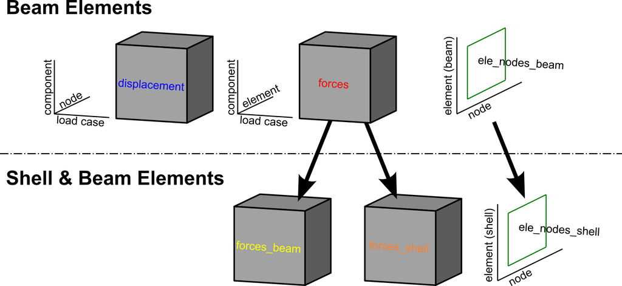

```python
display.Image(b64decode(data_structure_png))
```

To extract DataArray of displacement components:

```python
static_lc_displacements = static_lc_result.displacements
```

To extract DataArray of force components:

```python
static_lc_forces = static_lc_result.forces
```

#### Extract elements and nodes of Beam 1

Before we extract results of a Beam 1 (the `"exterior_main_beam_1"` of the model), we identify the elements and nodes of that grillage element.

With `ospgrillage`, we can query the element and node numbers using `get_element()` function and the name of standard element as defined previously during `set_member()` step.

```python
member_name = "exterior_main_beam_1"
```

Now, get the tag of elements and nodes:

```python
ext_beam_elements = model.get_element(member=member_name, options="elements",)
print(f"The element tags for Beam 1 is {ext_beam_elements}")
```

```
The element tags for Beam 1 is [20, 33, 46, 59, 72, 85, 98, 111, 124, 131]
```

```python
ext_beam_nodes = model.get_element(member=member_name, options="nodes")
print(f"The node tags for Beam 1 is {ext_beam_nodes[0]}")
```

```
The node tags for Beam 1 is [2, 16, 23, 30, 37, 44, 51, 58, 65, 72, 9]
```

#### Selecting a specific load case from result

We extract for each load case and compare with values in Table 3 of Caprani et al. (2017).

```python
load_case_name = ['M1600 L1','M1600 L2', 'M1600 L3']
```

We extract maximum bending moment of Beam 1 (`member_name`) from `static_lc_forces` as before:

```python
max_bending = 0
for i in range(3):
    max_bending += max(static_lc_forces.sel(Loadcase=load_case_name[i],
                                              Component="Mz_i",Element=ext_beam_elements)).values/1000
print(f" Maximum bending moment = {max_bending:.2f} kNm")
```

```
 Maximum bending moment = 5224.48 kNm
```

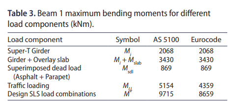

```python
display.Image(b64decode(table_png))
```

#### Plotting results

We can plot force and displacement components from `results` using `plot_force()` and `plot_defo` functions respectively.

Plot BMD and deflection for Beam 1 of Figure 1 (i.e. "exterior_main_beam_1" of `model`).

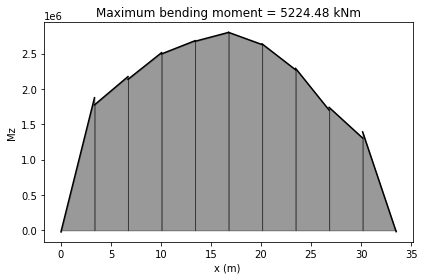

```python
load_case_of_interest = load_case_name[0] # M1600 L1
og.plot_force(model, results, member="exterior_main_beam_1",component="Mz",loadcase=load_case_of_interest)

max_report_bending = f"Maximum bending moment = {max_bending:.2f} kNm"

og.plt.title(max_report_bending);
```

We can also plot for deflections. Here we plot the deflections for `M1600 L1` load case

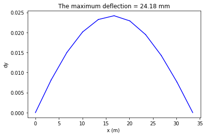

```python
max_def = max(results.displacements.sel(Loadcase=load_case_name[0],Component="dy",Node=ext_beam_nodes[0]))
max_report_def = f"The maximum deflection = {max_def.values*1000:.2f} mm"

og.plot_defo(model, results, member="exterior_main_beam_1", option="nodes",loadcase=load_case_of_interest)
og.plt.title(max_report_def);
```

#### Design SLS combination

Load combinations for AS5100 serviceability limit state (SLS) can be calculated from load case `results` as well.

The factors are 1.0, 1.0 and 1.3 for DL, Traffic, and SIDL load cases respectively.

```python
DL_factor = 1.0
LL_factor = 1.0
SIDL_factor = 1.3
```

To get combinations, pass into the keyword`combinations=` of `get_results()` function a dictionary with load case names as keys and corresponding load factors as values:

```python
load_combinations = {'Super T self weight':DL_factor,
                     'M1600 L1':LL_factor,
                     'M1600 L2':LL_factor,
                     'M1600 L3':LL_factor,
                     'SIDL':SIDL_factor,
                     'Overlay self weight':DL_factor}

combination_results = model.get_results(combinations=load_combinations)
combination_results
```

```
<xarray.Dataset>
Dimensions:        (Component: 18, Element: 136, Node: 77, Nodes: 2)
Coordinates:
  * Component      (Component) <U7 'Mx_i' 'Mx_j' 'My_i' ... 'theta_y' 'theta_z'
  * Node           (Node) int32 1 2 3 4 5 6 7 8 9 ... 69 70 71 72 73 74 75 76 77
  * Element        (Element) int32 1 2 3 4 5 6 7 ... 130 131 132 133 134 135 136
  * Nodes          (Nodes) <U1 'i' 'j'
Data variables:
    displacements  (Node, Component) object nan nan nan ... 0.0 -0.005425
    forces         (Element, Component) float64 -2.965e+05 -3.011e+05 ... nan
    ele_nodes      (Element, Nodes) object 6.3 12.6 12.6 ... 81.9 485.1 88.2
```

Similarly, we can extract maximum mid span bending moment about Z axis from `combination_results`.

```python
comb_bending = combination_results.forces.sel(Component="Mz_i",Element=ext_beam_elements)

print(f"Load combination max BM = {max(comb_bending.values/1000):.2f} kN m") # Table 3 - 9715 kNm
```

```
Load combination max BM = 9261.28 kN m
```

### Envelope

We can create envelope of the analysis results - via `Envelope` feature of the post-processing module.

We will showcase with getting envelopes for static load cases and then we consider moving load later on.

By using `create_envelope()` function and passing in `static_lc_results`, a reduced xarray (in the dimension on load case) is returned based on the specificed maxima (either "max" or "min").

```python
envelope = og.create_envelope(ds=static_lc_result,load_effect="Mz_i",array="forces") # creates the envelope obj
bending_env = envelope.get() # class function
bending_env
```

```
<xarray.DataArray 'forces' (Element: 136, Component: 18)>
array([[-17213.56987636,  -5274.96043951,     -0.        , ...,
                    nan,             nan,             nan],
       [ 88874.17905883,  76434.55070556,     -0.        , ...,
                    nan,             nan,             nan],
       [ 61092.0229278 ,  62816.04762452,     -0.        , ...,
                    nan,             nan,             nan],
       ...,
       [ 95863.68052984,  37022.89326926,      0.        , ...,
                    nan,             nan,             nan],
       [ 81844.01187186, -11005.8583736 ,      0.        , ...,
                    nan,             nan,             nan],
       [ 67991.14031026,  -9026.87239132,      0.        , ...,
                    nan,             nan,             nan]])
Coordinates:
  * Component  (Component) <U7 'Mx_i' 'Mx_j' 'My_i' ... 'theta_y' 'theta_z'
  * Element    (Element) int32 1 2 3 4 5 6 7 8 ... 130 131 132 133 134 135 136
```

Now for Moving load:

```python
max_moving_envelope = og.create_envelope(ds=moving_results,load_effect="Mz_i",array="forces")
max_force_env = max_moving_envelope.get()
max_force_env.sel(Element=ext_beam_elements,Component="Mz_i")
```

```
<xarray.DataArray 'forces' (Element: 10)>
array([   3210.35829841,  319206.79999751,  639582.04057052,
        929481.75948615, 1115940.57526875, 1182102.40474546,
       1123563.20381475,  937486.07218405,  638754.13914878,
        305993.27828757])
Coordinates:
    Component  <U7 'Mz_i'
  * Element    (Element) int32 20 33 46 59 72 85 98 111 124 131
```

We can query where these maxima occurred i.e. which load cases are these from

```python
max_moving_envelope = og.create_envelope(ds=moving_results,load_effect="Mz_i",array="forces",query_mode=True)
max_force_query_env = max_moving_envelope.get()
```

We then extract envelope for Beam 1 only:

```python
query_max_load_case = max_force_query_env.sel(Element=ext_beam_elements,Component="Mz_i")
query_max_load_case
```

```
<xarray.DataArray 'Loadcase' (Element: 10)>
array(['Moving M1600 L2 at global position [-1.12,0.00,0.00]',
       'Moving M1600 L2 at global position [0.07,0.00,0.00]',
       'Moving M1600 L2 at global position [0.07,0.00,0.00]',
       'Moving M1600 L2 at global position [1.27,0.00,0.00]',
       'Moving M1600 L2 at global position [2.46,0.00,0.00]',
       'Moving M1600 L2 at global position [2.46,0.00,0.00]',
       'Moving M1600 L2 at global position [3.65,0.00,0.00]',
       'Moving M1600 L2 at global position [4.85,0.00,0.00]',
       'Moving M1600 L2 at global position [6.04,0.00,0.00]',
       'Moving M1600 L2 at global position [6.04,0.00,0.00]'],
      dtype=object)
Coordinates:
    Component  <U7 'Mz_i'
  * Element    (Element) int32 20 33 46 59 72 85 98 111 124 131
```

## Shell model

Next, we explore a modern model template available in ospgrillage - the Shell and Beam element model.

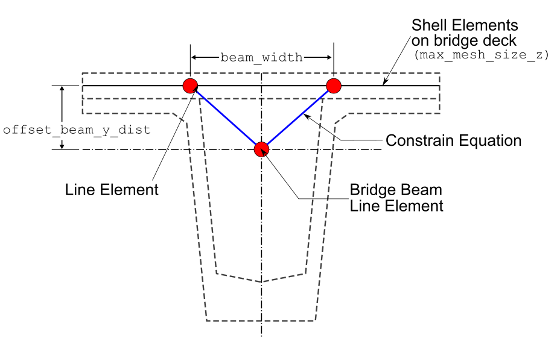

```python
display.Image(b64decode(shell_beam_ideal_png))
```

For this model we use the same properties for beam elements except this time we define Section properties of slab.

Define a slab depth:

```python
slab_depth = 0.18 * m
```

Create a shell section - ospgrillage automatically detects this as shell when a cross-section depth, h is set.

```python
slab_shell_section = og.create_section(h=slab_depth)
```

Create a grillage member then assigning the material and shell section

```python
slab_shell = og.create_member(section=slab_shell_section, material=concrete)
```

Creating a new model call `shell_model`. Similar to traditional model, we set the members of the model.

```python
shell_model = og.create_grillage(
    bridge_name="Super-T 33_5m",
    long_dim=L,
    width=w,
    skew=angle,
    num_long_grid=n_l,
    num_trans_grid=n_t,
    edge_beam_dist=edge_dist,
    model_type="shell_beam",
    max_mesh_size_z=1,
    max_mesh_size_x=1,
    offset_beam_y_dist=0.499,
    beam_width=0.89
)
```

```python
# set beams
shell_model.set_member(longitudinal_beam, member="interior_main_beam")
shell_model.set_member(longitudinal_beam, member="exterior_main_beam_1")
shell_model.set_member(longitudinal_beam, member="exterior_main_beam_2")
# set shell
shell_model.set_shell_members(slab_shell)
```

Create the model in OpenSees

```python
shell_model.create_osp_model(pyfile=False)
```

Plot the model using `GetRendering` - currently `ops_vis` is not able to visualize mix element model (shell + beam)

```
No Model_ODB specified, trying to get data from the active model.
3D model
```

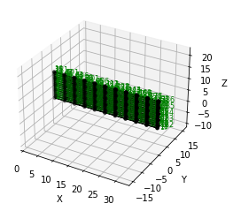

```python
og.opsplt.plot_model("nodes");
```

Now we simply add the previously defined load cases to shell model. Following this, we analyze the load cases.

```python
shell_model.add_load_case(DL_self_weight)
shell_model.add_load_case(DL_overlay)
shell_model.add_load_case(SIDL)
for i in range(3):
    shell_model.add_load_case(m1600_lc_list[i])
    shell_model.add_load_case(moving_load_list[i])
```

### Analyse

```python
shell_model.analyze()
```

```python
shell_results = shell_model.get_results()
shell_results
```

```
<xarray.Dataset>
Dimensions:          (Component: 30, Element: 200, Loadcase: 156, Node: 231, Nodes: 4)
Coordinates:
  * Component        (Component) <U7 'Mx_i' 'Mx_j' ... 'theta_y' 'theta_z'
  * Loadcase         (Loadcase) <U53 'Super T self weight' ... 'Moving M1600 ...
  * Node             (Node) int32 1 2 3 4 5 6 7 ... 225 226 227 228 229 230 231
  * Element          (Element) int64 326 327 328 329 330 ... 521 522 523 524 525
  * Nodes            (Nodes) <U1 'i' 'j' 'k' 'l'
Data variables:
    displacements    (Loadcase, Node, Component) object nan nan ... 7.654e-06
    forces_beam      (Loadcase, Element, Component) float64 1.747e+04 ... nan
    forces_shell     (Loadcase, Element, Component) float64 nan nan ... nan nan
    ele_nodes_beam   (Element, Nodes) float64 177.0 187.0 nan ... nan nan nan
    ele_nodes_shell  (Element, Nodes) float64 nan nan nan ... 31.0 32.0 176.0
```

Let's compare the static M1600 results with those from the beam model. Here we do the same as before: adding the bending moment of Beam 1 from each lane load cases (L1, L2, and L3).

```python
ext_beam_elements_shell = shell_model.get_element(member=member_name, options="elements",)

shell_max_bending = 0
for i in range(3):
    shell_max_bending += max(shell_results.forces_beam.sel(Loadcase=load_case_name[i],
                                              Component="Mz_i",Element=ext_beam_elements_shell)).values/1000

print(f"Maximum bending shell model is {shell_max_bending:.2f} kNm")
print(f"Maximum bending beam model is {max_bending :.2f} kNm")
```

```
Maximum bending shell model is 4822.51 kNm
Maximum bending beam model is 5224.48 kNm
```

## References

[1]. Caprani, C.C. & Melhem, M.M. & Siamphukdee, K. (2017). Reliability analysis of a Super-T prestressed concrete girder at serviceability limit state to AS 5100:2017. *Australian Journal of Structural Engineering*. 18. 1-13. 10.1080/13287982.2017.1332843.